# Molecular Marker Assisted Plant Breeding

Simple Interval Mapping (IM)

Felipe Ferrão

University of Florida

**Objectives:**

- 60 minutes of hands-on
- Conditional probability
- Simple interval mapping

**Extra information**

- [HOS 6236 – Website](https://lfelipe-ferrao.github.io/class/mas/)
- About the [author](https://lfelipe-ferrao.github.io/)
- About the [UF/IFAS Plant Breeding](https://programs.ifas.ufl.edu/plant-breeding/)

# Introduction

So far, we have applied single marker regression, a method that treats each genetic marker independently to test for association with the trait of interest. While useful as an initial scan, this approach does not incorporate any information from the **linkage map** or account for the relationships between adjacent markers.

By incorporating a linkage map, we gain a more powerful framework that allows us to leverage recombination information and genetic distances between markers. This enables us to analyze a **grid of positions along the genome** —not just the markers themselves—as potential locations for quantitative trait loci (QTL). This approach is the foundation of interval mapping and related methods.

Consider the example below, where a QTL lies somewhere between Marker 8 and Marker 9. We cannot observe the QTL directly—it’s latent—but we do observe the flanking markers. The idea is to examine the genome position by position, using marker data to estimate the probability that a QTL is located in a particular region.

To implement this approach, two key concepts come into play:

- Conditional probabilities – These represent the probability of each possible QTL genotype at a given position, conditional on the observed flanking marker genotypes. This accounts for recombination and is derived from the linkage map.
- Haley–Knott regression methods.

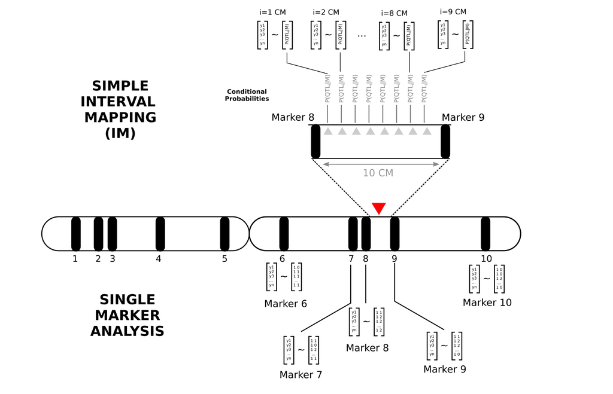

Example of simple interval mapping compared to single marker regression

# Conditional Probabilities

## Toy example: drawing cards from a deck

By definition, we can use the probability rules to compute the **conditional probability** of an event $A$ occur, given that event $B$ has occurred. Using equations, this is defined as:

$$P(A \mid B) = \frac{P(A \cap
B)}{P(B)}$$

Where:

- $P(A \mid B)$: Probability of event A given B has occurred
- $P(A \cap B)$: Probability of both A and B occurring
- $P(B)$: Probability of event B

Let’s exemplify it by drawing cards from a deck. If we consider a standard deck of 52 playing cards:

- **26 red cards** (13 hearts + 13 diamonds)
- **26 black cards** (13 spades + 13 clubs)
- **12 face cards** total: 3 face cards per suit (Jack, Queen, King × 4 suits = 12)

Assuming the two main event, we want to calculate: “Given that I have a red card, what is the probability to be a face card (Jack, Queen, King) ?

- $A$: The card is **a face card**
- $B$: The card is **red**
- $P(\text{Face card} \mid \text{Red card}) = ?$

**Step 1: Determine Counts**

- Total red cards = 26
- Red face cards = 6 (Jack, Queen, King of ♥️ and ♦️)
- So:
  - $P(\text{Red}) = \frac{26}{52}$
  - $P(\text{Face} \cap \text{Red}) = \frac{6}{52}$

**Step 2: Apply the Formula**

$$P(\text{Face card} \mid \text{Red card}) = \frac{P(\text{Face} \cap
\text{Red})}{P(\text{Red})}
= \frac{\frac{6}{52}}{\frac{26}{52}} = \frac{6}{26} = \frac{3}{13}$$

If you know that a drawn card is **red**, the probability that it is **also a face card** is **3 out of 13**, or about **23.1%**.

Why this is important? Analogous to the card example, where we can ask “Given that a card is a face card (B), what is the probability it is a Queen (A)?”, in the QTL mapping problem we can ask ““Given the marker genotypes (flanking markers), what is the probability that the QTL genotype at position is Qq or qq?”.

## QTL population

### BC population

We will expand the conditional probability ideas to cases where we have markers and QTL. Let’s consider a linear chromossome with three loci:

```
M1 <---> QTL  <---> M2
```

There two important information in this simple linear representation:

- QTL information is a latent variable. In another words, we can not observe the QTL information and we would like to infer about the genotype of the QTL based on the flanking markers M1 and M2.
- There are two important metrics here: $r_1$ that is the recombination fraction between Marker 1 and QTL and the $r_2$, that is the recombination fraction between QTL and Marker 2.

To compute the probabilities, we should consider some information:

- **$1 - r$** represents the probability of **no recombination** in a given interval.
- **$r$** represents the probability of **a recombination** occurring.

We can expand the recombination information into four possible recombination patterns, assuming recombination events between the QTL and one of the flanking markers, as follow:

| Pattern | M1–QTL Recomb? | QTL–M2 Recomb? | Inherited Segment (F1-derived) | Resulting QTL Genotype | Probability Expression |
| --- | --- | --- | --- | --- | --- |
| 1 | No | No | `A–Q–B` | `Qq` | $(1 - r_1)(1 - r_2)$ |
| 2 | No | Yes | `A–Q–b` | `Qq` | $(1 - r_1)r_2$ |
| 3 | Yes | No | `a–q–B` | `qq` | $r_1(1 - r_2)$ |
| 4 | Yes | Yes | `a–q–b` | `qq` | $r_1 r_2$ |

**General Formula**

$$P(Q = g \mid M_1 = m_1, M_2 = m_2) = \frac{P(Q = g, M_1 = m_1, M_2 =
m_2)}{\sum\limits_{g'} P(Q = g', M_1 = m_1, M_2 = m_2)}$$

Where: - $g \in \{Qq, qq\}$ - The numerator is the **joint probability** of a specific QTL genotype and observed marker genotypes - The denominator is the **total probability**

In the example below, look how the probability expression will change when assuming different recombination value, with r_1 = 0.1 and r_2 = 0.2

| Recombination Pattern | Probability |
| --- | --- |
| No recomb (1 - r1)(1 - r2) | 0.9 × 0.8 = 0.72 |
| Right only (1 - r1)(r2) | 0.9 × 0.2 = 0.18 |
| Left only (r1)(1 - r2) | 0.1 × 0.8 = 0.08 |
| Both recomb (r1)(r2) | 0.1 × 0.2 = 0.02 |

### F2 population

Notice how the calculations become more complex in an **F2 population**. This increased complexity arises because F2 individuals can have **three possible genotypes at each locus** (e.g., `AA`, `Aa`, `aa`), compared to only two in a backcross. As a result, the number of possible genotype combinations—and thus the number of rows in the conditional probability table—increases significantly.

However, all required probabilities can still be derived using the same principles we’ve discussed in class:

- **Conditional probabilities**
- **Recombination fractions (r)**
- **Mendelian segregation ratios**

Despite the added detail, the foundational logic remains the same. The F2 case simply requires us to track more genotype classes, and apply conditional reasoning more carefully.

| **Genotype** | **QQ** | **Qq** | **qq** |
| --- | --- | --- | --- |
| $M_1M_1,\; M_2M_2$ | $\dfrac{(1-r_a)^2(1-r_b)^2}{(1-r)^2}$ | $\dfrac{2\,r_a(1-r_a)\,r_b(1-r_b)}{(1-r)^2}$ | $\dfrac{r_a^{2} r_b^{2}}{(1-r)^2}$ |
| $M_1M_1,\; M_2m_2$ | $\dfrac{2(1-r_a)^2\,r_b(1-r_b)}{2r(1-r)}$ | $\dfrac{2\,r_a(1-r_a)\,[r_b^{2}+(1-r_b)^{2}]}{2r(1-r)}$ | $\dfrac{2\,r_a^{2}\,r_b(1-r_b)}{2r(1-r)}$ |
| $M_1M_1,\; m_2m_2$ | $\dfrac{(1-r_a)^{2} r_b^{2}}{r^{2}}$ | $\dfrac{2\,r_a(1-r_a)\,r_b(1-r_b)}{r^{2}}$ | $\dfrac{r_a^{2}(1-r_b)^{2}}{r^{2}}$ |
| $M_1m_1,\; M_2M_2$ | $\dfrac{2\,r_a(1-r_a)\,(1-r_b)^{2}}{2r(1-r)}$ | $\dfrac{2\,[r_a^{2}+(1-r_a)^{2}]\,r_b(1-r_b)}{2r(1-r)}$ | $\dfrac{2\,r_a(1-r_a)\,r_b^{2}}{2r(1-r)}$ |
| $M_1m_1,\; M_2m_2$ | $\dfrac{4\,r_a(1-r_a)\,r_b(1-r_b)}{2\left[(1-r)^{2}+r^{2}\right]}$ | $\dfrac{2\,[r_a^{2}+(1-r_a)^{2}]\,[r_b^{2}+(1-r_b)^{2}]}{2\left[(1-r)^{2}+r^{2}\right]}$ | $\dfrac{4\,r_a(1-r_a)\,r_b(1-r_b)}{2\left[(1-r)^{2}+r^{2}\right]}$ |
| $M_1m_1,\; m_2m_2$ | $\dfrac{2\,r_a(1-r_a)\,r_b^{2}}{2r(1-r)}$ | $\dfrac{2\,[r_a^{2}+(1-r_a)^{2}]\,r_b(1-r_b)}{2r(1-r)}$ | $\dfrac{2\,r_a(1-r_a)\,(1-r_b)^{2}}{2r(1-r)}$ |
| $m_1m_1,\; M_2M_2$ | $\dfrac{r_a^{2}(1-r_b)^{2}}{r^{2}}$ | $\dfrac{2\,r_a(1-r_a)\,r_b(1-r_b)}{r^{2}}$ | $\dfrac{(1-r_a)^{2} r_b^{2}}{r^{2}}$ |
| $m_1m_1,\; M_2m_2$ | $\dfrac{2\,r_a^{2}\,r_b(1-r_b)}{2r(1-r)}$ | $\dfrac{2\,r_a(1-r_a)\,[r_b^{2}+(1-r_b)^{2}]}{2r(1-r)}$ | $\dfrac{2\,(1-r_a)^{2}\,r_b(1-r_b)}{2r(1-r)}$ |
| $m_1m_1,\; m_2m_2$ | $\dfrac{r_a^{2} r_b^{2}}{(1-r)^{2}}$ | $\dfrac{2\,r_a(1-r_a)\,r_b(1-r_b)}{(1-r)^{2}}$ | $\dfrac{(1-r_a)^{2}(1-r_b)^{2}}{(1-r)^{2}}$ |

where:

- $r_a$ is the recombination fraction between the marker 1 and the QTL
- $r_b$ is the recombination fraction between the marker 2 and the QTL
- $r$ is the recombination fraction between the both markers
- In this example, we assumer interference to be zero.

# Haley-Knott Regression

We already know that linear models are essential tools for associating genotypic and phenotypic information in QTL analysis. In single-marker regression, this association is established by regressing the observed genotype at a single marker directly on the phenotypic trait. While straightforward, this method considers each marker independently and does not make use of the linkage information between markers or the possible location of a QTL between them.

To improve upon this, interval mapping introduces the concept of Haley-Knott regression, which allows us to evaluate positions between markers—where the actual QTL is most likely to reside. Although the underlying linear model structure remains the same, the key difference is that, in interval mapping, the explanatory variable is no longer a fixed genotype but rather the conditional probabilities of each QTL genotype given the observed flanking marker data. These probabilities are computed based on the recombination fractions between the QTL and the markers.

$$y_j = \mu + \beta x^{\ast}_j +
e_j$$

- $y$ : phenotypic value for the individual j
- $\mu$ : intercept
- $x^{\ast}_j$ : conditional probabilities
- $\beta_j$: slope of the regression that will measure the marker effect

By incorporating these probabilities into the regression model, interval mapping allows us to scan the genome at regular intervals and test for the presence of a QTL at each position. This approach leverages both genetic linkage and quantitative genetics principles to provide more accurate localization and estimation of QTL effects compared to single-marker regression.

In the example below, we use an F2 population to illustrate how the structure of the incidence matrix changes depending on the recombination fraction values. Different values of r affect the conditional probabilities of QTL genotypes given marker genotypes, which in turn alters the explanatory variables in the model.

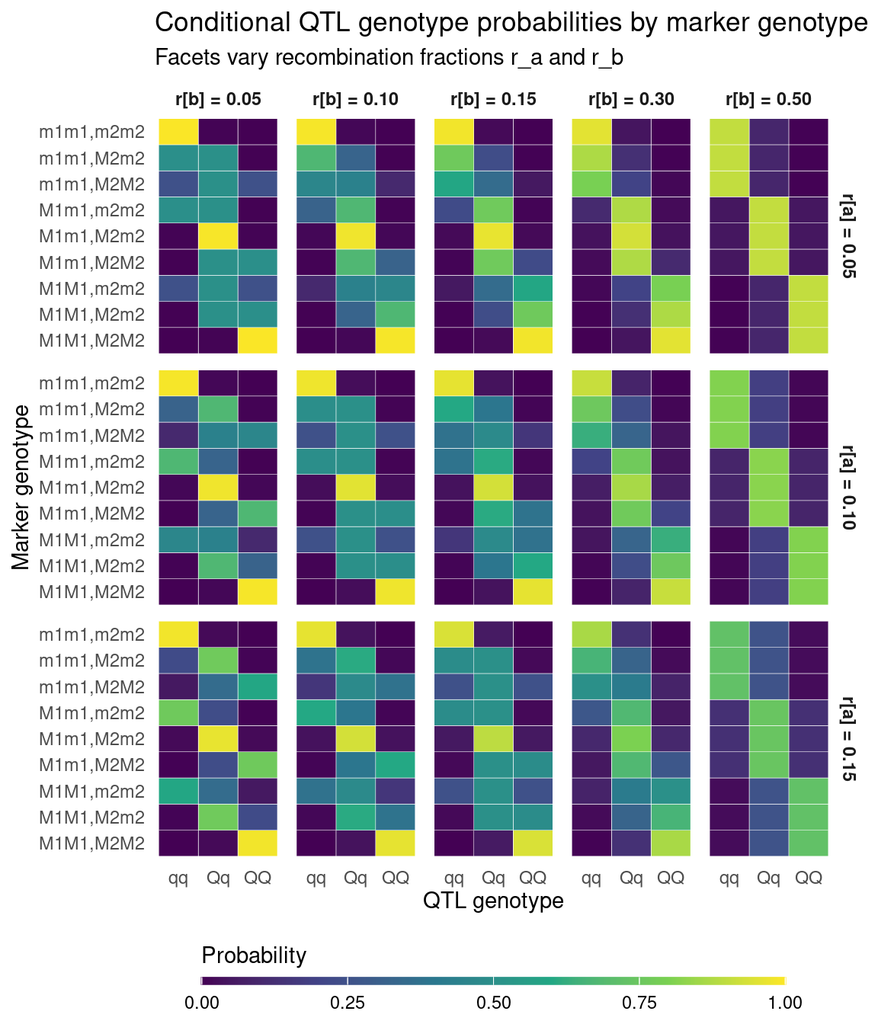

In QTL mapping, we systematically scan the genome by evaluating positions at regular intervals, typically measured in centimorgans (cM), to identify regions that may harbor quantitative trait loci (QTL). At each position, we test whether the genetic variation at that location is significantly associated with variation in the trait of interest.

To formally test it, we will compare models with and without a QTL at a specific genomic position using the **likelihood function**. The goal is to determine whether including a QTL significantly improves the fit of the model to the phenotypic data.

- **Null Model (Reduced Model)**: assumes no QTL effect
- **Full Model**: includes QTL effects based on conditional genotype probabilities
- $LOD= \dfrac{n}{2}log_{10}\dfrac{RSS_0}{RSS1}$, where the $RSS_0$ is null residual sum of squares and the $RSS_1$ is the residual sum for the regression.

To test the significance of the QTL, where a **higher LOD score** indicates stronger evidence for a QTL at that genomic position. By scanning across genomic positions and computing the LOD score at each point, we build a **LOD profile**, identifying peaks that suggest the presence of QTLs.

# Hands-on

For the sequence of this tutorial, we will use the same example from the Single Marker Regression.

- Sugiyama et al., (2002): QTL associated with blood pressure, heart rate, and heart weight in CBA/CaJ and BALB/cJ mice. Physiol Genomics 10:5–12. [Link](https://journals.physiology.org/doi/full/10.1152/physiolgenomics.00002.2002)
- Number of individuals: 163
- 93 markers
- F2 population

```r
library(qtl)
sug <-  read.cross("csv",
                  "/home/felipe/Dropbox (UFL)/classes/Molecular_Breeding/class3_QTLMapping/",
                  "QTLmapping_6.csv",
                  genotypes=c("CC", "CB",   "BB"),
                  alleles=c("C",    "B"))
```

```
##  --Read the following data:
##   163  individuals
##   93  markers
##   6  phenotypes
##  --Cross type: f2
```

```r
# SINGLE MARKER REGRESSION  (homework)
mr <- scanone(sug, pheno.col=3,method="mr")
summary(mr,threshold = 2.6) # QTL threshold > 2.5 (naive threshold)
```

```
##           chr  pos  lod
## D15MIT184  15 22.8 6.61
## D16MIT5    16 34.2 2.70
```

```r
# INTERVAL MAPPING
# -- Simple linear regression,considering a grid of positions along the genome
hyper = calc.genoprob(sug,step=1) # cond. prob
IM.hk = scanone(hyper, pheno.col = 3, method = "hk")
head(IM.hk) #LOD for each position of the linkage mapping ("sweeping the genome")
```

```
##          chr  pos       lod
## D1MIT171   1 15.4 0.5852395
## c1.loc1    1 16.4 0.5470558
## c1.loc2    1 17.4 0.5074486
## c1.loc3    1 18.4 0.4666536
## c1.loc4    1 19.4 0.4249879
## c1.loc5    1 20.4 0.3828550
```

```r
summary(IM.hk,threshold = 2.6) # QTL threshold > 2.5 (naive threshold)
```

```
##           chr  pos  lod
## c3.loc23    3 33.8 2.76
## c15.loc16  15 20.0 6.75
## c16.loc22  16 36.7 2.74
```

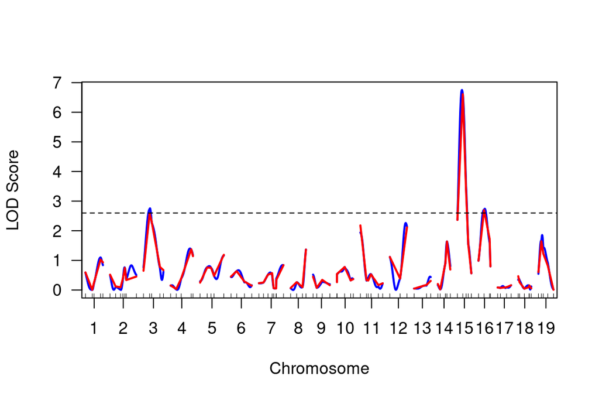

```r
# Plot
chr <- c(1:19)
plot(IM.hk, mr, chr = chr, col = c("blue", "red"), ylab = "LOD Score")
abline(h = 2.6, lty = 2, col="black") # naive threshold
```

# References

- Lander, E. S., & Botstein, D. (1989). *Genetics*, 121(1), 185–199.
- Broman, K. W., & Sen, Ś. (2009). *A Guide to QTL Mapping with R/qtl*. Springer.
- Haley, C. S., & Knott, S. A. (1992). *Heredity*, 69(4), 315–324.
- Lynch, M., & Walsh, B. (1998). *Genetics and Analysis of Quantitative Traits*.

[figure not shown]